# Global Superstore Transaction Data Analysis with R

Wan Ying Hsu; Chueh Yang

23/9/2021

# 1 **Introduction**

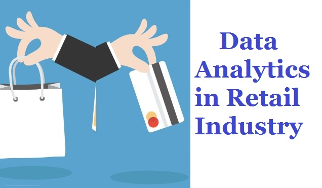

**Global Superstore firm** - is a fast grow retailer who offers office supplies, electronics and telecommunication goods through internet. The head of the company expect to optimize its resource by understanding the sales performance for further business development as well as CRM service. Thus, the data science team was assigned with a transaction data that was collect from 2012 to 2015.

The dataset contains 51,290 rows with 24 variables. There are three sheets in the original dataset, **“Orders”**, **“Returns”** and **“People”**. **“Orders”** is a transaction based dataset which contains all orders that have been placed across entire global markets. **“Returns”** refers to a list of all returned orders. Nevertheless, there is no indication of the variables in the **“People”** sheet, thus we do not consifer this table in our analysis.

**Globbal_superstore_2016.xlsx**, was collected from data.world (source: https://data.world/vikas-0731/global-super-store ).

## 1.1 **Importing Data**

The original sheet **“Orders”** is as below,

| Row ID | Order ID | Order Date | Ship Date | Ship Mode | Customer ID | Customer Name | Segment | Postal Code | City | State | Country | Region | Market | Product ID | Category | Sub-Category | Product Name | Sales | Quantity | Discount | Profit | Shipping Cost | Order Priority |
| --- | --- | --- | --- | --- | --- | --- | --- | --- | --- | --- | --- | --- | --- | --- | --- | --- | --- | --- | --- | --- | --- | --- | --- |
| 40098 | CA-2014-AB10015140-41954 | 2014-11-11 | 2014-11-13 | First Class | AB-100151402 | Aaron Bergman | Consumer | 73120 | Oklahoma City | Oklahoma | United States | Central US | USCA | TEC-PH-5816 | Technology | Phones | Samsung Convoy 3 | 222 | 2 | 0.0 | 62 | 41 | High |
| 26341 | IN-2014-JR162107-41675 | 2014-02-05 | 2014-02-07 | Second Class | JR-162107 | Justin Ritter | Corporate | NA | Wollongong | New South Wales | Australia | Oceania | Asia Pacific | FUR-CH-5379 | Furniture | Chairs | Novimex Executive Leather Armchair, Black | 3709 | 9 | 0.1 | -289 | 924 | Critical |
| 25330 | IN-2014-CR127307-41929 | 2014-10-17 | 2014-10-18 | First Class | CR-127307 | Craig Reiter | Consumer | NA | Brisbane | Queensland | Australia | Oceania | Asia Pacific | TEC-PH-5356 | Technology | Phones | Nokia Smart Phone, with Caller ID | 5175 | 9 | 0.1 | 920 | 915 | Medium |
| 13524 | ES-2014-KM1637548-41667 | 2014-01-28 | 2014-01-30 | First Class | KM-1637548 | Katherine Murray | Home Office | NA | Berlin | Berlin | Germany | Western Europe | Europe | TEC-PH-5267 | Technology | Phones | Motorola Smart Phone, Cordless | 2893 | 5 | 0.1 | -97 | 910 | Medium |
| 47221 | SG-2014-RH9495111-41948 | 2014-11-05 | 2014-11-06 | Same Day | RH-9495111 | Rick Hansen | Consumer | NA | Dakar | Dakar | Senegal | Western Africa | Africa | TEC-CO-6011 | Technology | Copiers | Sharp Wireless Fax, High-Speed | 2833 | 8 | 0.0 | 312 | 903 | Critical |
| 22732 | IN-2014-JM156557-41818 | 2014-06-28 | 2014-07-01 | Second Class | JM-156557 | Jim Mitchum | Corporate | NA | Sydney | New South Wales | Australia | Oceania | Asia Pacific | TEC-PH-5842 | Technology | Phones | Samsung Smart Phone, with Caller ID | 2863 | 5 | 0.1 | 763 | 897 | Critical |
| 30570 | IN-2012-TS2134092-41219 | 2012-11-06 | 2012-11-08 | First Class | TS-2134092 | Toby Swindell | Consumer | NA | Porirua | Wellington | New Zealand | Oceania | Asia Pacific | FUR-CH-5378 | Furniture | Chairs | Novimex Executive Leather Armchair, Adjustable | 1822 | 4 | 0.0 | 565 | 895 | Critical |

The Data variables, type and description are shown in the following table.  
**Data variables and description:**

| *Variables* | *Type* | *Description* |
| --- | --- | --- |
| **Row ID** | numeric | The ID number of rows |
| **Order ID** | character | The ID of orders |
| **Order Date** | YYYY-MM-DD | The date that orders have been placed |
| **Ship Date** | YYYY-MM-DD | The date that orders have been shipped |
| **Ship Mode** | character | The mode of shipping |
| **Customer ID** | character | The ID of customers |
| **Customer Name** | character | The name of customers |
| **Segment** | character | The type of customers |
| **Postal Code** | numeric | The postal code of customer’s location (only applied in USA) |
| **City** | character | The city of customer’s location |
| **State** | character | The state of customer’s location |
| **Country** | character | The country of customer’s location |
| **Region** | character | The region of customer’s country |
| **Market** | character | The market to which the customer’s location belongs |
| **Product ID** | character | The ID of products |
| **Category** | character | The category to which the product belongs |
| **Sub-Category** | character | The subcategory to which the product belongs |
| **Product Name** | character | The full name of the product |
| **Sales** | numeric | The sales amount of the product |
| **Quantity** | numeric | The sales quantity of the product |
| **Profit** | numeric | The profit of the product |
| **Shipping Cost** | numeric | The shipping fee of the product |
| **Order Priority** | character | The priority of the order |

## 1.2 **Data Inspection**

### 1.2.1 Data clearning and preparing

First of all, data was inspected to see whether any NaN values and duplicated rows existing. Some column names included space, for the coding purpose, we transform all column names into lowercase with underscore. Then, duplicated and uninterested features are deleted.

- Remove **Return** orders from the main **Orders** sheet
- Remove **Row ID** and **Postal Code** from order table

```r
# delete unnecessary column
orders <- orders[,-which(colnames(orders) %in% c("Row ID","Postal Code"))]

#checked duplicated and missing data
anyDuplicated(orders)
anyDuplicated(returns)
sum(is.na(orders))
sum(is.na(returns))

# rename column name
colnames(orders) <- tolower(gsub(" ", "_", colnames(orders)))
colnames(returns) <- tolower(gsub(" ", "_", colnames(returns)))
names(orders)[names(orders) == 'segment'] <- 'customer_type0'
names(orders)[names(orders) == 'category'] <- 'category0'
names(orders)[names(orders) == 'sub-category'] <- 'sub_category0'
names(orders)[names(orders) == 'order_priority'] <- 'order_priority0'
```

- The **order_date** was divided into year, month, day, and number of week respectively

The character variables with different categories were transferred to categorical variables. After reordering the columns, the dataset was ready for further process. The final data structure is as follows.

```r
# delete return order
orders <-orders[!(orders$order_id %in% returns$order_id),]


# transfer the date respectively to year, month, day, week

orders$year <- year(orders$order_date)
orders$month <- month(orders$order_date)
orders$day <- day(orders$order_date)
orders$week <- week(orders$order_date)

# transfer the character variable to categorical variables
col <- c("customer_type0", "category0", "sub_category0", "order_priority0")
orders[col] <- lapply(orders[col], factor)

# create the new column for categorical variables

orders <- orders %>%
  mutate(customer_type=fct_recode(customer_type0,
                                   "1" = "Consumer",
                                   "2" = "Corporate",
                                   "3" = "Home Office"))

orders <- orders %>%
  mutate(category=fct_recode(category0,
                                   "1" = "Furniture",
                                   "2" = "Office Supplies",
                                   "3" = "Technology"))

orders <- orders %>%
  mutate(sub_category=fct_recode(sub_category0,
                                   "1" = "Accessories",
                                   "2" = "Appliances",
                                   "3" = "Art",
                                   "4" = "Binders",
                                   "5" = "Bookcases",
                                   "6" = "Chairs",
                                   "7" = "Copiers",
                                   "8" = "Envelopes",
                                   "9" = "Fasteners",
                                   "10" = "Furnishings",
                                   "11" = "Labels",
                                   "12" = "Machines",
                                   "13" = "Paper",
                                   "14" = "Phones",
                                   "15" = "Storage",
                                   "16" = "Supplies",
                                   "17" = "Tables"))


orders <- orders %>%
  mutate(order_priority=fct_recode(order_priority0,
                                   "1" = "Critical",
                                   "2" = "High",
                                   "3" = "Medium",
                                   "4" = "Low"))

# reorder column
orders <- orders[c("order_id", "order_date", "year", "month", "day", "week", "ship_date", "ship_mode", "customer_id", "customer_name", "customer_type0", "customer_type", "city", "state", "country", "region",  "market", "product_id", "category0", "category", "sub_category0", "sub_category", "product_name", "sales", "quantity", "discount", "profit", "shipping_cost", "order_priority0", "order_priority")]

cols <- c("customer_type", "category", "sub_category", "order_priority")
orders[cols] <- lapply(orders[cols], factor)

# Delete negative quantity
orders <- orders %>%
  mutate(quantity = replace(quantity, quantity <= 0, NA)) #

# export csv file
write.csv(orders, file="../Data/orders.csv", row.names = F)

# final data
glimpse(orders)
```

```
## Rows: 49,070
## Columns: 30
## $ order_id        <chr> "CA-2014-AB10015140-41954", "IN-2014-JR162107-41675", ~
## $ order_date      <dttm> 2014-11-11, 2014-02-05, 2014-10-17, 2014-01-28, 2014-~
## $ year            <dbl> 2014, 2014, 2014, 2014, 2014, 2014, 2012, 2013, 2014, ~
## $ month           <dbl> 11, 2, 10, 1, 11, 6, 11, 4, 11, 3, 3, 4, 12, 11, 6, 7,~
## $ day             <int> 11, 5, 17, 28, 5, 28, 6, 14, 11, 6, 6, 19, 26, 13, 6, ~
## $ week            <dbl> 45, 6, 42, 4, 45, 26, 45, 15, 45, 10, 10, 16, 52, 46, ~
## $ ship_date       <dttm> 2014-11-13, 2014-02-07, 2014-10-18, 2014-01-30, 2014-~
## $ ship_mode       <chr> "First Class", "Second Class", "First Class", "First C~
## $ customer_id     <chr> "AB-100151402", "JR-162107", "CR-127307", "KM-1637548"~
## $ customer_name   <chr> "Aaron Bergman", "Justin Ritter", "Craig Reiter", "Kat~
## $ customer_type0  <fct> Consumer, Corporate, Consumer, Home Office, Consumer, ~
## $ customer_type   <fct> 1, 2, 1, 3, 1, 2, 1, 1, 1, 1, 1, 2, 1, 3, 1, 2, 1, 2, ~
## $ city            <chr> "Oklahoma City", "Wollongong", "Brisbane", "Berlin", "~
```

[output cut: 17 more lines]

# 2 **Data Analysis**

As mentioned, the head of the company wish to generate insights from the transaction data. Thus, the use cases are derived after the first glance of the given dataset.

In order to implementing data-driven approach, we divided data into product-oriented and customer-centric data for the company’s CRM sales strategies. We will firstly take look of the customer related data that are namely customer ID, monetary value, frequency of purchasing and purchasing behaviors and respective markets together with transaction data such as order ID and product information to identify customer segment.

## 2.1 **Customer Data Analysis with RFM model**

To understand customer purchasing behavior, RFM analysis is applied for the use of estimating customer related data. Recency, Frequency of purchasing, and total Monetary Value as well as average spending are determined.

**RFM** is a classic analysis for segmenting customer into several groups that based on the recent interactions, purchase frequency and monetary contribution. In this section, we deal with part of the data from the order table. In order to conduct RFM analysis,a dataframe is created with a selection of customer information from the original dataset.

```r
#Create a variable max_date: the maximum of the order date, which will be use to calculate recency value
max_date <- max(orders$order_date)

rfm_df <- orders %>%
  group_by(customer_id) %>%
  summarise(recency = as.numeric(max_date -max(order_date)),
            frequency = n_distinct(order_id), monetary = sum(sales)/n_distinct(order_id))
summary(rfm_df) #summary of recency, monetary values
```

```
##  customer_id           recency       frequency      monetary
##  Length:16956       Min.   :   0   Min.   :1.0   Min.   :    1
##  Class :character   1st Qu.: 151   1st Qu.:1.0   1st Qu.:   82
##  Mode  :character   Median : 425   Median :1.0   Median :  245
##                     Mean   : 510   Mean   :1.5   Mean   :  481
##                     3rd Qu.: 807   3rd Qu.:2.0   3rd Qu.:  614
##                     Max.   :1460   Max.   :9.0   Max.   :11835
```

### 2.1.1 **RFM Graphical Analysis**

Let’s compare the summary of `rfm_df`, and the RFM Graphical Analysis, strong right skew tendency is found in the RFM value graph. And, it is clear to see major of customers only purchase once, with average spending amount is 481 and average return purchase are made at around 510 days. Therefore, a product analysis also need to be checked in order to understand the cause of low average spending amount of most of customers.

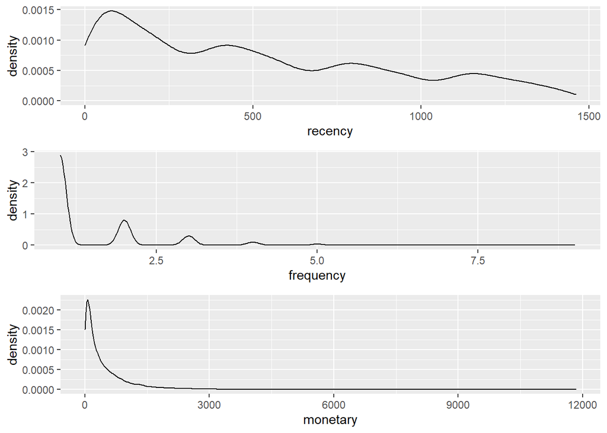

```r
library(gridExtra)
r <- ggplot(rfm_df) + geom_density(aes(x = recency))
f <- ggplot(rfm_df) + geom_density(aes(x= frequency))
m <- ggplot(rfm_df) + geom_density(aes(x = monetary))
grid.arrange(r, f, m, nrow =3)
```

### 2.1.2 **Building RFM Segment**

The methodology of RFM often used in business sectors, it allows business to group customers to optimize business resource for various use cases such as sales promotion, marketing campaign or customer retention. The RFM analysis consists three main variables:

- **Recency** : Identify the date that customers made the last purchase
- **Frequency**: Analysis frequency of purchase in a defined time
- **Monetary**: Evaluate a customer average spending in a period of time

In order to perform RFM segment, we need to calculate the RFM value for each customer, we will extract some features that are needed for the RFM Analysis. Here we create a `rfm_df` by grouping data with unique `customer_id`, and three variables are created based on the selection features:

- **customer_id**: The unique customer entry of each customer
- **max_date**: The latest order date in the raw dataset
- **order_date**: To understand customer purchase behavior
- **order_id**: To calculate how many order per customer made
- **sales**: The sum of customer spending

```r
rfm_df$Rscore <- cut(rfm_df$recency, 5, labels = c(5,4,3,2,1))
rfm_df$Fscore <- cut(rfm_df$frequency, 5, labels = F)
rfm_df$Mscore <- cut(rfm_df$monetary, 5, labels = F)
rfm_df$Rscore <- as.numeric(rfm_df$Rscore)
head(rfm_df)
```

| customer_id | recency | frequency | monetary | Rscore | Fscore | Mscore |
| --- | --- | --- | --- | --- | --- | --- |
| AA-10315102 | 358 | 2 | 272 | 2 | 1 | 1 |
| AA-10315120 | 959 | 1 | 2713 | 4 | 1 | 2 |
| AA-10315139 | 149 | 4 | 739 | 1 | 2 | 1 |
| AA-103151402 | 184 | 2 | 2390 | 1 | 1 | 2 |
| AA-103151404 | 818 | 2 | 377 | 3 | 1 | 1 |
| AA-103151406 | 1203 | 1 | 30 | 5 | 1 | 1 |

**Sorting data with decending order with RFM score value**

```r
rfm_df <- rfm_df[with(rfm_df, order(-Rscore, -Fscore, -Mscore)), ]
```

**Creating RFM score group**

```r
RFMscore<- rfm_df$Rscore*100 + rfm_df$Fscore*10 + rfm_df$Mscore
rfm_df<- cbind(rfm_df, RFMscore)

head(rfm_df, n = 20)
```

|  | customer_id | recency | frequency | monetary | Rscore | Fscore | Mscore | RFMscore |
| --- | --- | --- | --- | --- | --- | --- | --- | --- |
| 1 | AS-63095 | 1273 | 3 | 337 | 5 | 2 | 1 | 521 |
| 2 | BT-153060 | 1295 | 3 | 165 | 5 | 2 | 1 | 521 |
| 3 | KT-1646518 | 1293 | 3 | 315 | 5 | 2 | 1 | 521 |
| 4 | NM-184451404 | 1348 | 3 | 188 | 5 | 2 | 1 | 521 |
| 5 | RC-19960139 | 1181 | 3 | 347 | 5 | 2 | 1 | 521 |
| 6 | BM-111401402 | 1210 | 1 | 10540 | 5 | 1 | 5 | 515 |
| 7 | CA-1196566 | 1420 | 1 | 7508 | 5 | 1 | 4 | 514 |
| 8 | BP-11155139 | 1239 | 1 | 5382 | 5 | 1 | 3 | 513 |
| 9 | Dl-13600130 | 1210 | 1 | 4821 | 5 | 1 | 3 | 513 |
| 10 | HL-1504011 | 1369 | 1 | 4734 | 5 | 1 | 3 | 513 |

[output cut: 10 more lines]

```r
rfm_df$RFMgroup <-as.factor(rfm_df$RFMscore)
rfm_df<- rfm_df %>%
  group_by(RFMgroup) %>%
  mutate(group_no = n_distinct(customer_id))

rfm_df %>%
  head() %>%
  kable() %>%
  kable_minimal()
```

| customer_id | recency | frequency | monetary | Rscore | Fscore | Mscore | RFMscore | RFMgroup | group_no |
| --- | --- | --- | --- | --- | --- | --- | --- | --- | --- |
| AS-63095 | 1273 | 3 | 337 | 5 | 2 | 1 | 521 | 521 | 5 |
| BT-153060 | 1295 | 3 | 165 | 5 | 2 | 1 | 521 | 521 | 5 |
| KT-1646518 | 1293 | 3 | 315 | 5 | 2 | 1 | 521 | 521 | 5 |
| NM-184451404 | 1348 | 3 | 188 | 5 | 2 | 1 | 521 | 521 | 5 |
| RC-19960139 | 1181 | 3 | 347 | 5 | 2 | 1 | 521 | 521 | 5 |
| BM-111401402 | 1210 | 1 | 10540 | 5 | 1 | 5 | 515 | 515 | 1 |

**Graphical analysis with RFM group distribution**

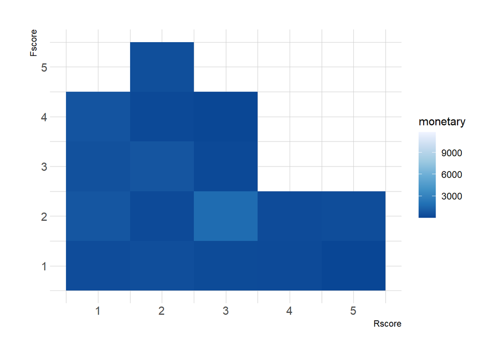

```r
ggplot(rfm_df, aes(Rscore, Fscore, fill= monetary))+
  geom_tile() +
  scale_fill_distiller(palette = "Blues") +
  theme_ipsum()
```

**Graphical analysis with number of customer per RFM group**

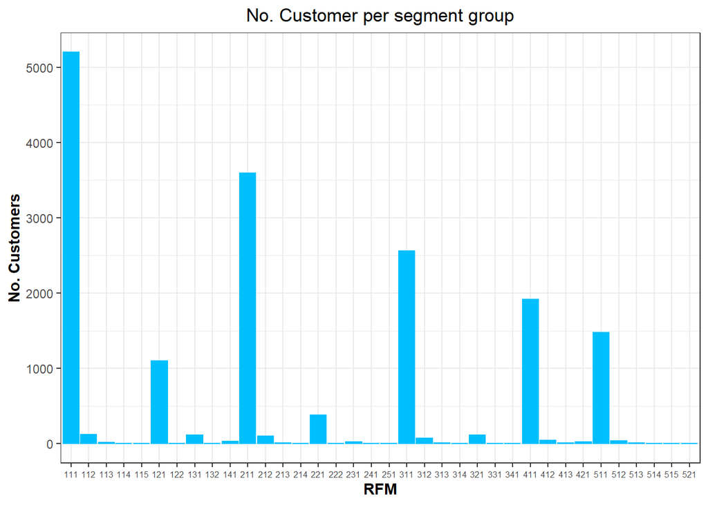

```r
ggplot(rfm_df, aes(factor(RFMscore))) +
  geom_bar(color = "deepskyblue1", fill = "deepskyblue1" ) +
  labs(x = "RFM", y = "No. Customers", title = "No. Customer per segment group") +
  theme(plot.title = element_text(face = "bold", size = 16, hjust = 10)) +
  theme_bw() +
  theme(axis.title = element_text( face = "bold"), plot.title = element_text(hjust = 0.5),axis.text.x = element_text(size = 6))
```

**Clustering Analysis**  
Here, we perform a hierarchical cluster analysis using a set of dissimilarities.

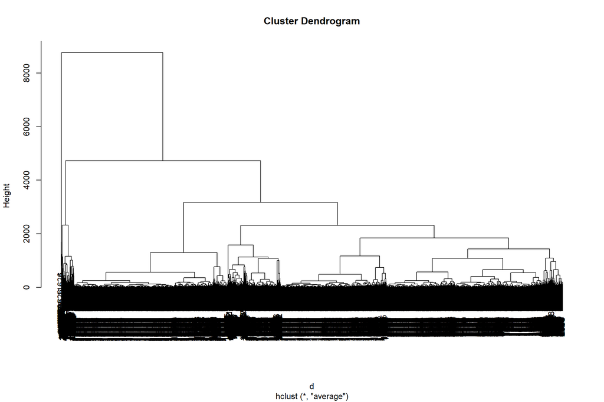

```r
rfm_df2 <- rfm_df
d <- dist(rfm_df2)
c <- hclust(d, method = 'average')

plot(c)
```

**The output of this clustering analysis was not ideal for the interpretation**. Other setting or machine learning methods should be test for carrying out better result. Therefore, the goal of the customer data analysis is to identified who are the most value customers, and how are we going to utiliz historical data to predict customer lifetime value in next project.

## 2.2 **Product Data Analysis**

In this section, we continue use the same dataset but with product-oriented focus to carry out sales performance analysis in the following sections.

### 2.2.1 **Sales vs. Subcategory**

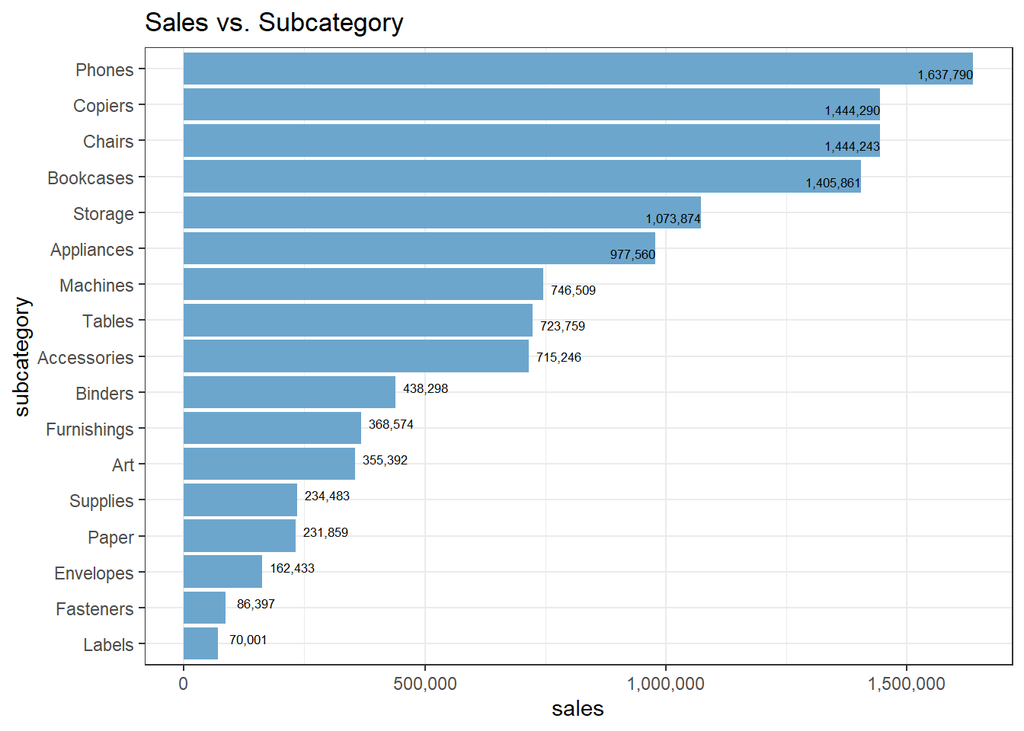

```r
# Sales vs. Subcategory(all)
ggplot(orders %>% group_by(sub_category0) %>% summarize_at("sales",sum,na.rm=TRUE), aes(x = reorder(sub_category0, sales), y = sales)) +
  geom_bar(stat="identity", fill = "skyblue3")  +
  labs(x = "subcategory", y = "sales", title = "Sales vs. Subcategory") +
  theme(plot.title = element_text(hjust = 0.5)) +
  geom_text(aes(label=format(sales, big.mark = ",")), position = position_dodge(0.8),vjust="inward",hjust="inward", size = 2.3) +
  scale_y_continuous(labels = comma) +
  theme_bw() +
  coord_flip()
```

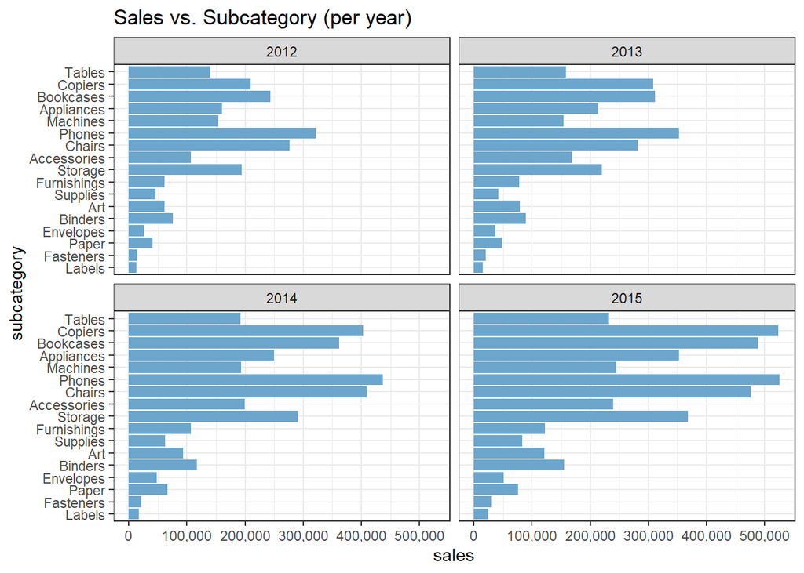

```r
# Sales vs. Subcategory(by year)
ggplot(data=orders, aes(x = reorder(sub_category0, sales), y = sales)) +
  stat_summary(fun = "sum", geom = "bar", position = "identity", fill = "skyblue3") +
  facet_wrap(~year) +
  labs(x = "subcategory", y = "sales", title = "Sales vs. Subcategory (per year)") +
  theme(plot.title = element_text(hjust = 0.5)) +
  scale_y_continuous(labels = comma) +
  theme_bw() +
  coord_flip()
```

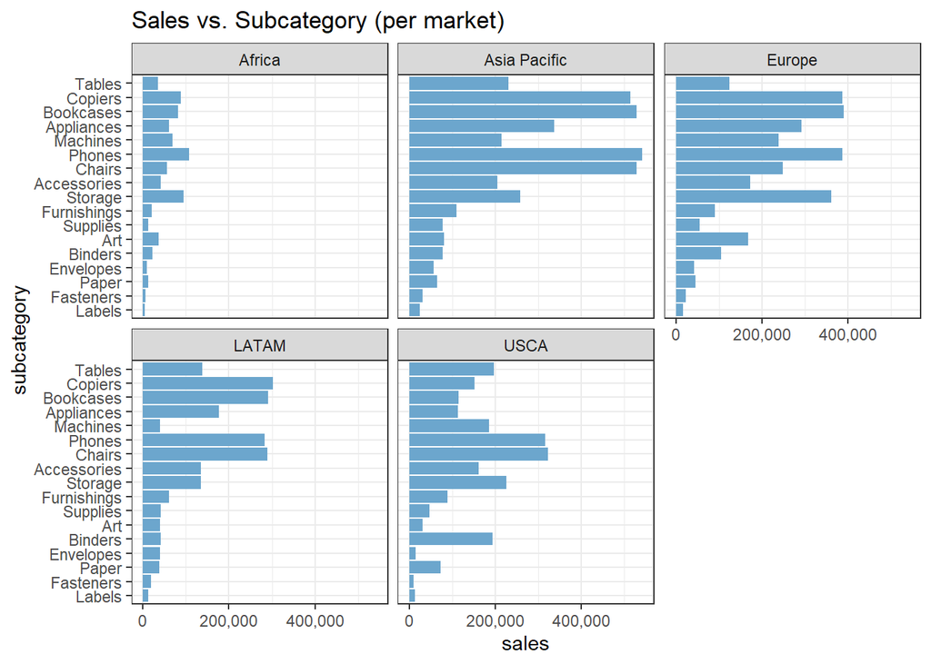

```r
# Sales vs. Subcategory(by market)
ggplot(data=orders, aes(x = reorder(sub_category0, sales), y = sales)) +
  stat_summary(fun = "sum", geom = "bar", position = "identity", fill = "skyblue3") +
  facet_wrap(~market) +
  labs(x = "subcategory", y = "sales", title = "Sales vs. Subcategory (per market)") +
  theme(plot.title = element_text(hjust = 0.5)) +
  scale_y_continuous(labels = comma) +
  theme_bw() +
  coord_flip()
```

### 2.2.2 **Sales/Profit vs. Subcategory**

Compared to sales ranking of subcategory, profit ranking of subcategory is slightly different, especially the negative profit of Tables is observed.

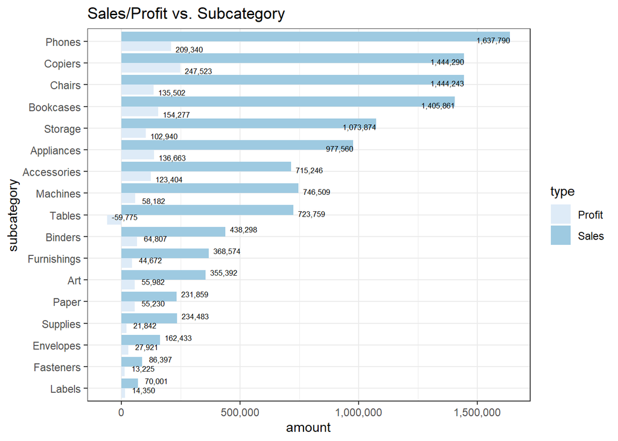

```r
# Profit vs. Subcategory
orderSP <-
  orders %>% group_by(sub_category0) %>%
  summarize(Sales =sum(sales), Profit =sum(profit)) %>%
  pivot_longer(cols = -sub_category0,
               names_to = "type",
               values_to = "results")

ggplot(orderSP, aes(x = reorder(sub_category0, results), y = results, fill = type)) +
  geom_bar(stat="identity", position="dodge") +
  labs(x = "subcategory", y = "amount", title = "Sales/Profit vs. Subcategory") +
  theme(plot.title = element_text(hjust = 0.5)) +
  geom_text(aes(label=format(results, big.mark = ",")), position = position_dodge(0.85), vjust="inward",hjust="inward", size = 2.3) +
  scale_y_continuous(labels = comma) +
  scale_fill_brewer(palette = "Blues") +
  theme_bw() +
  coord_flip()
```

### 2.2.3 **Top 20 Sales vs. Product**

The following graph displays the global top 20 best sellers from 2012 to 2015.

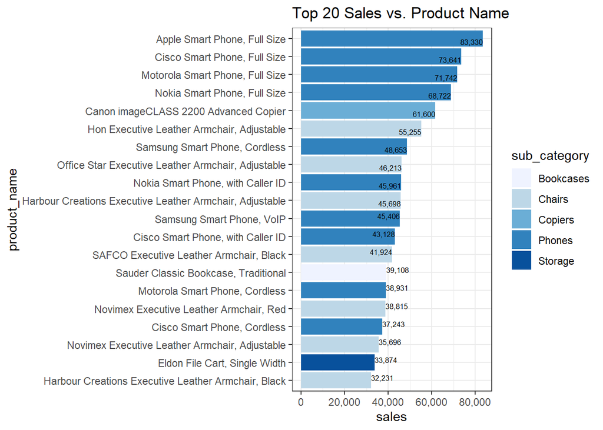

```r
# Top 20 Sales vs. Product Name (all)
top20pros <- orders %>% group_by(product_name) %>% summarize_at("sales",sum,na.rm=TRUE) %>% top_n(20, sales)
prolist0 <- data.frame(sub_category = orders$sub_category0, product_name = orders$product_name)
prolist0 <- prolist0[!duplicated(prolist0$product_name), ]
prolists <- merge(x = top20pros, y = prolist0, by = "product_name", all.x = TRUE)

# Top 20 Sales vs. Product Name (all)
ggplot(prolists, aes(x = reorder(product_name, sales), y = sales, fill = sub_category)) +
  geom_bar(stat="identity")  +
  labs(x = "product_name", y = "sales", title = "Top 20 Sales vs. Product Name") +
  theme(plot.title = element_text(hjust = 0.5)) +
  geom_text(aes(label=format(sales, big.mark = ",")), position = position_dodge(0.85), vjust="inward",hjust="inward", size = 2.3)+
  scale_fill_brewer(palette = "Blues") +
  scale_y_continuous(labels = comma) +
  theme_bw() +
  coord_flip()
```

The top 5 best sellers in each market is diverse. Except USCA (United States and Canada), “phones” is the most popular category among other markets. USCA’s best sellers are all office equipment.

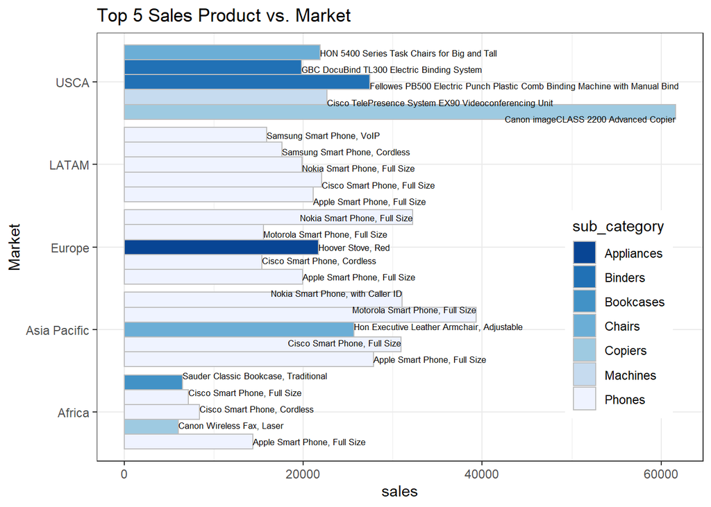

```r
# Top 5 Sales vs. Product Name (per market)

top5prosx <- orders %>% group_by(market, product_name) %>%summarize_at("sales",sum,na.rm=TRUE)%>% top_n(5, sales)
top5prosx <- merge(x = top5prosx, y = prolist0, by = "product_name", all.x = TRUE)

ggplot(data = top5prosx, aes(x = market, y = sales, group= product_name, fill =sub_category)) +
  geom_bar(stat="identity", position="dodge", color="gray") +
  labs(x = "Market", y = "sales", title = "Top 5 Sales Product vs. Market") +
  theme(plot.title = element_text(hjust = 0.5)) +
  geom_text(aes(label=product_name), position = position_dodge(1), vjust="inward",hjust="inward", size = 2.3)+
  scale_fill_brewer(palette = "Blues", direction = -1) +
  theme_bw() +
  theme(
    legend.position = c(.95, .1),
    legend.justification = c("right", "bottom")
    ) +
  coord_flip()
```

### 2.2.4 **Growth Rate vs. Subcategory**

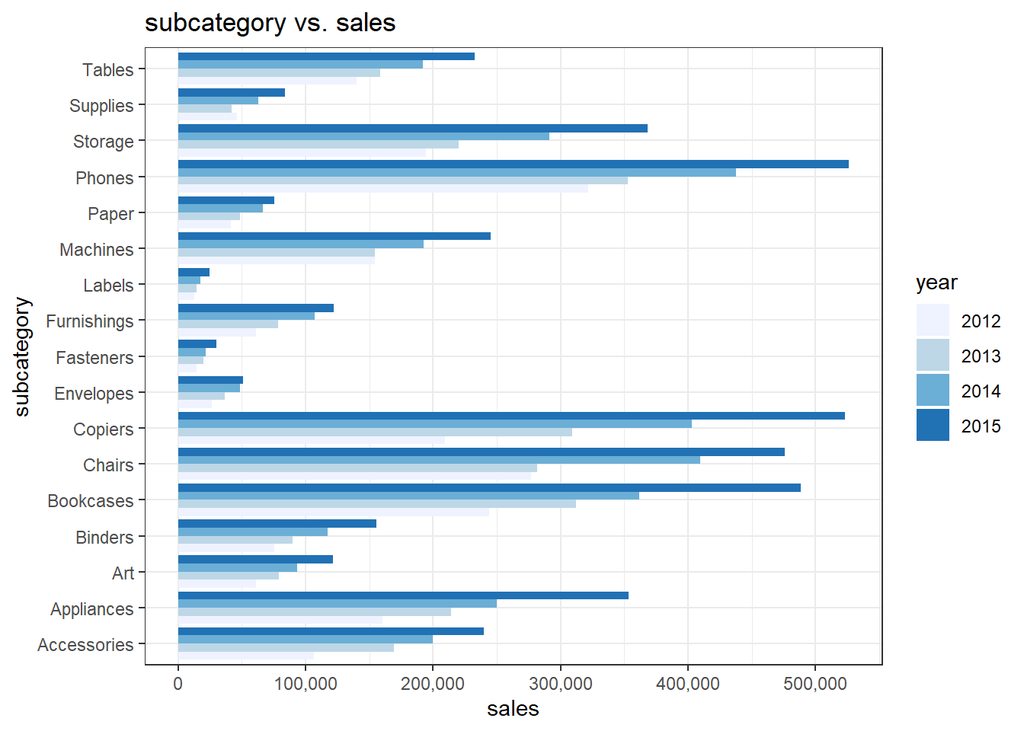

```r
#  sales vs. subcategory
ordersy0 <-
  orders %>% group_by(year,sub_category0) %>% summarize(sum_sales =sum(sales)) %>% pivot_wider(names_from = "year", values_from = "sum_sales")

ordersy0 <-
ordersy0  %>% pivot_longer(cols = -sub_category0, names_to = "year", values_to = "sales")


ggplot(data = ordersy0, aes(x = sub_category0, y = sales, fill = year)) +
  geom_bar(stat="identity", position="dodge") +
  labs(x = "subcategory", y = "sales", title = "subcategory vs. sales") +
  theme(plot.title = element_text(hjust = 0.5)) +
  scale_fill_brewer(palette = "Blues") +
  scale_y_continuous(labels = comma) +
  theme_bw() +
  coord_flip()
```

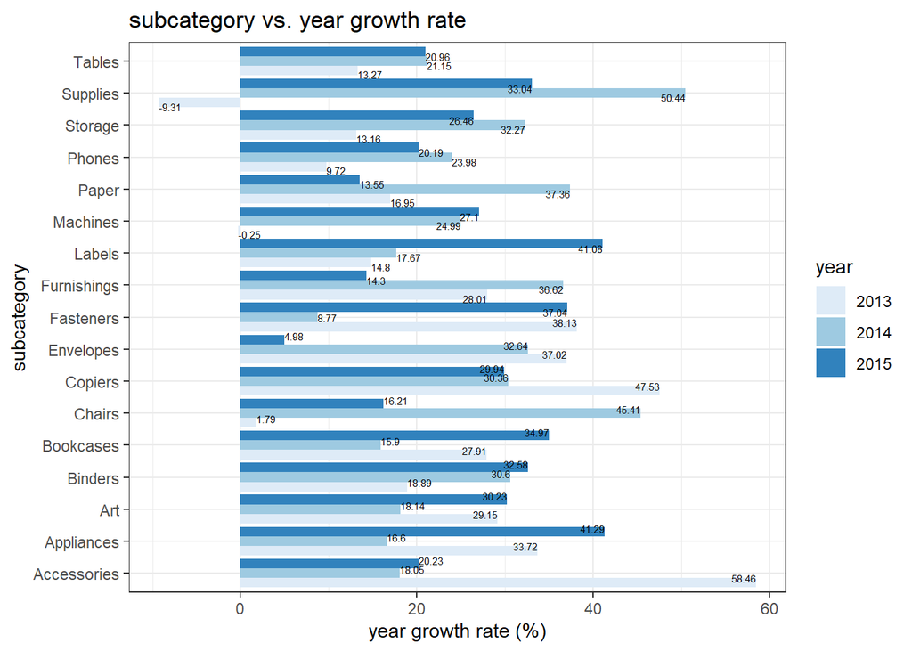

```r
# year growth rate vs. subcategory
ordersy <-
  orders %>% group_by(year,sub_category0) %>% summarize(sum_sales =sum(sales)) %>% pivot_wider(names_from = "year", values_from = "sum_sales")

names(ordersy)[names(ordersy) == "2012"] <- "r2012"
names(ordersy)[names(ordersy) == "2013"] <- "r2013"
names(ordersy)[names(ordersy) == "2014"] <- "r2014"
names(ordersy)[names(ordersy) == "2015"] <- "r2015"

ordersgr <-
ordersy %>% mutate(gr2013 = (r2013 - r2012)/r2012*100) %>% mutate(gr2014 = (r2014 - r2013)/r2013*100) %>% mutate(gr2015 = (r2015 - r2014)/r2014*100) %>% select(sub_category0, gr2013, gr2014, gr2015) %>% pivot_longer(cols = -sub_category0, names_to = "year", values_to = "growth_rate")

ordersgr$year <- gsub("gr", "", ordersgr$year)

ggplot(data = ordersgr, aes(x = sub_category0, y = growth_rate, fill = year)) +
  geom_bar(stat="identity", position="dodge") +
  labs(x = "subcategory", y = "year growth rate (%)", title = "subcategory vs. year growth rate") +
  theme(plot.title = element_text(hjust = 0.5)) +
  geom_text(aes(label=round(growth_rate, digits= 2)), position = position_dodge(0.85), vjust="inward",hjust="inward", size = 2)+
  scale_fill_brewer(palette = "Blues") +
  theme_bw() +
  coord_flip()
```

## 2.3 **Region Analysis** ( the section of our choice)

This section is selected to be an additional section that is to demonstrate the R packages, `map` and `gridExtra`, that was not mentioned in the R bootcamp course.

- `map` is used to project maps with geographical data, and map data frame is downloaded via `map` and combined with analyzed dataset for map display.
- `GridExtra` is used to arrange multiple grid-based plots on the same output.

### 2.3.1 **Sales map**

From 2012 to 2015, sales amount of United States ranked first in the world, and the subsequent four countries in the ranking are Australia, France, China, and Germany.

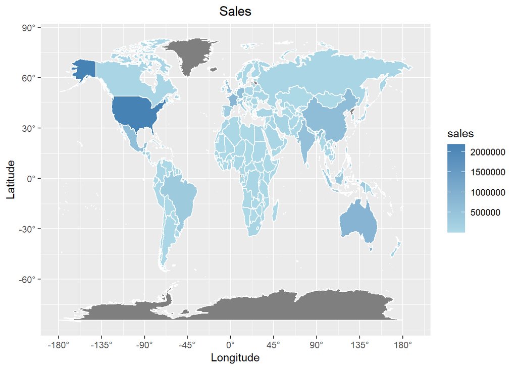

```r
# map data process
world_map <-map_data("world")

world_map$region <- gsub("USA", "United States", world_map$region)
world_map$region <- gsub("UK", "United Kingdom", world_map$region)
world_map$region <- gsub("Republic of Congo", "Republic of the Congo", world_map$region)
world_map$region <- gsub("Ivory Coast", "Cote d'Ivoire", world_map$region)
world_map$region <- gsub("Myanmar", "Myanmar (Burma)", world_map$region)


mapsales <- orders %>% group_by(country) %>% summarize_at("sales",sum,na.rm=TRUE)
mapsales <- world_map %>% left_join(mapsales,by = c("region" = "country"))

# country vs. sales (all)
ggplot(mapsales, aes(x = long, y = lat, group = group)) +
  geom_polygon(aes(fill = sales), color = "white")  +
  scale_x_continuous(breaks = seq(-180, 210, 45), labels = function(x){paste0(x,"°")}) +
  scale_y_continuous(breaks = seq(-60, 100, 30), labels = function(x){paste0(x,"°")}) +
  scale_fill_gradient(low = "lightblue", high = "steel blue") +
  labs(x = "Longitude", y = "Latitude", title = "Sales") +
  theme(plot.title = element_text(hjust = 0.5), )
```

### 2.3.2 **Sales map (per year)**

The distribution of yearly sales by region can refer to the following four maps. The overall trend had not changed much during 2012 to 2015.

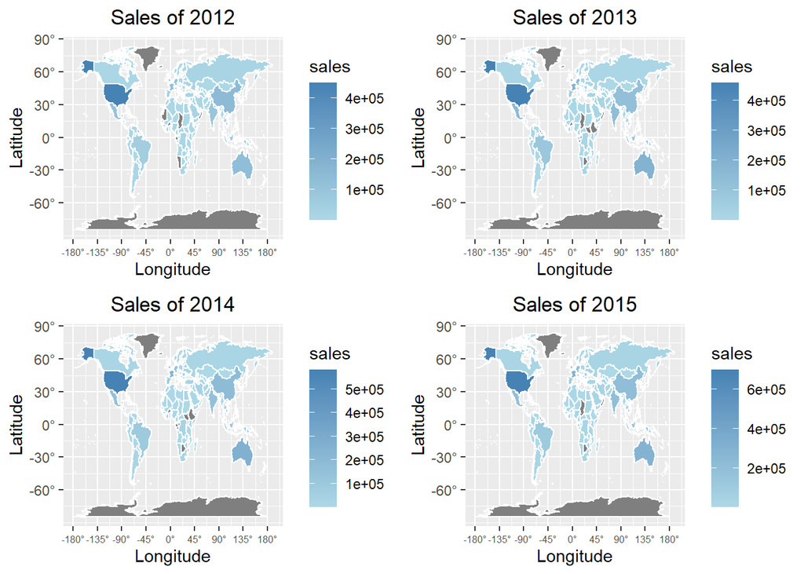

```r
## country vs.sales per year

fcsy <- function(x){
  mapsalesy <- orders %>% filter(year %in% x) %>% group_by(country) %>% summarize_at("sales",sum,na.rm=TRUE)
  mapsalesy <- world_map %>% left_join(mapsalesy,by = c("region" = "country"))

  ggplot(mapsalesy, aes(x = long, y = lat, group = group)) +
  geom_polygon(aes(fill = sales), color = "white")  +
  scale_x_continuous(breaks = seq(-180, 210, 45), labels = function(a){paste0(a,"°")}) +
  scale_y_continuous(breaks = seq(-60, 100, 30), labels = function(b){paste0(b,"°")}) +
  scale_fill_gradient(low = "lightblue", high = "steel blue") +
  labs(x = "Longitude", y = "Latitude", title = paste0("Sales of ", x)) +
  theme(plot.title = element_text(hjust = 0.5),axis.text.x = element_text(size = 6))

}

s2012 <- fcsy(2012)
s2013 <- fcsy(2013)
s2014 <- fcsy(2014)
s2015 <- fcsy(2015)
grid.arrange(s2012, s2013, s2014, s2015, ncol = 2)
```

# 3 **Product Recommendation** (Prediction)

A modeling is also given to identify product sold pattern based on the association rule analysis in this section, this model will allow as to introduce a new feature **recommendation** to the stores/ online retailers.

## 3.1 **Frequent Purchased Items**

The method used for product recommendation is **Association Analysis**. Its typical application is the analysis of buying behavior in stores and online retailers. They record the contents of shopping carts which are checkout. By finding frequent itemsets, they can learn what is commonly bought together and use this information to increase sales.

To understand the frequent itemsets and logic of association rule, a transaction’s dataset is built, which consists ofeach order ID (transaction) and its purchased product(itemsets).

The frequent-itemsets are sets of items that appear in many of the transaction. The bar chart below shows the top 15 products with high relative item frequency.

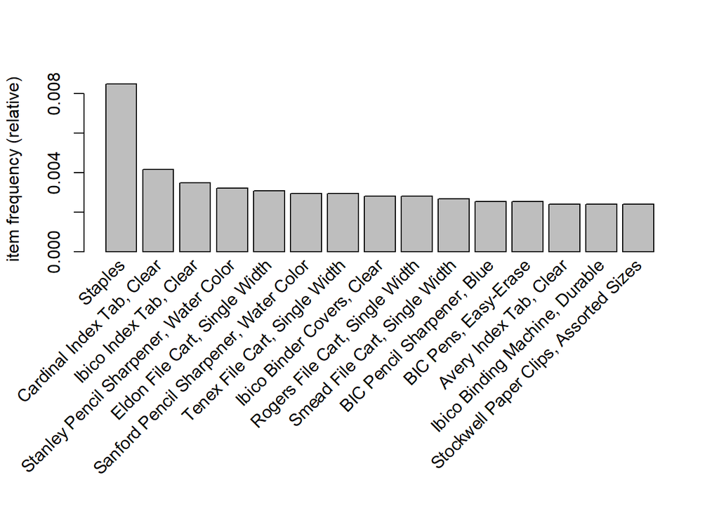

```r
#customer
listc <- read.csv("../Data/orders.csv") %>% filter(customer_type0 == "Corporate") %>% dplyr::select(order_id, product_name)

prodlistc <- list()
for(i in unique(listc$order_id)){

  prodlistc[[i]] <- listc[which(listc$order_id == i), 2]
}

prodlistc <- as(prodlistc, "transactions")

# the frequent items
itemFrequencyPlot(prodlistc,topN = 15)
```

## 3.2 **Association Rule Mining**

Association rule mining is based on the “market-basket” model from the data. `Apriori` function is used for extracting association rules. Parameter *support* and *confidence* are adjusted for selecting “relevant” rules from the set of all possible rules.

```r
# Rule
RulesRepc <- apriori(prodlistc, parameter = list(support=0.00025, confidence=0.0003, target = "rules",minlen = 2))
```

Here are the first 25 rule suggested. {LHS} is a set of items which customers purchased and {RHS} is an item which is recommended according to the association rules. The corresponding *support*, *confidence* and *lift* are also listd.

```r
# the first 10 rule
inspect(RulesRepc[1:25])
```

```
##      lhs                                                                            rhs                                                                         support confidence coverage lift count
## [1]  {Anker 36W 4-Port USB Wall Charger Travel Power Adapter for iPhone 5s 5c 5} => {Staples}                                                                   0.00027      0.667  0.00040   78     2
## [2]  {Staples}                                                                   => {Anker 36W 4-Port USB Wall Charger Travel Power Adapter for iPhone 5s 5c 5} 0.00027      0.032  0.00849   78     2
## [3]  {Satellite Sectional Post Binders}                                          => {Staples}                                                                   0.00027      0.667  0.00040   78     2
## [4]  {Staples}                                                                   => {Satellite Sectional Post Binders}                                          0.00027      0.032  0.00849   78     2
## [5]  {Ames Business Envelopes, Set of 50}                                        => {Harbour Creations Removable Labels, Adjustable}                            0.00027      0.400  0.00067  212     2
## [6]  {Harbour Creations Removable Labels, Adjustable}                            => {Ames Business Envelopes, Set of 50}                                        0.00027      0.143  0.00189  212     2
## [7]  {Brother Copy Machine, High-Speed}                                          => {Avery Legal Exhibit Labels, 5000 Label Set}                                0.00027      0.400  0.00067  297     2
## [8]  {Avery Legal Exhibit Labels, 5000 Label Set}                                => {Brother Copy Machine, High-Speed}                                          0.00027      0.200  0.00135  297     2
## [9]  {Brother Copy Machine, High-Speed}                                          => {Kraft Manila Envelope, Set of 50}                                          0.00027      0.400  0.00067  270     2
## [10] {Kraft Manila Envelope, Set of 50}                                          => {Brother Copy Machine, High-Speed}                                          0.00027      0.182  0.00148  270     2
## [11] {Square Credit Card Reader, 4 1/2" x 4 1/2" x 1", White}                    => {Staples}                                                                   0.00027      0.667  0.00040   78     2
## [12] {Staples}                                                                   => {Square Credit Card Reader, 4 1/2" x 4 1/2" x 1", White}                    0.00027      0.032  0.00849   78     2
## [13] {Eaton Parchment Paper, Premium}                                            => {Hewlett Fax and Copier, High-Speed}                                        0.00027      0.333  0.00081  412     2
## [14] {Hewlett Fax and Copier, High-Speed}                                        => {Eaton Parchment Paper, Premium}                                            0.00027      0.333  0.00081  412     2
## [15] {Chromcraft Coffee Table, Rectangular}                                      => {Ikea Stackable Bookrack, Mobile}                                           0.00027      0.667  0.00040 1236     2
## [16] {Ikea Stackable Bookrack, Mobile}                                           => {Chromcraft Coffee Table, Rectangular}                                      0.00027      0.500  0.00054 1236     2
## [17] {Chromcraft Coffee Table, Rectangular}                                      => {Advantus Rubber Bands, 12 Pack}                                            0.00027      0.667  0.00040  450     2
## [18] {Advantus Rubber Bands, 12 Pack}                                            => {Chromcraft Coffee Table, Rectangular}                                      0.00027      0.182  0.00148  450     2
## [19] {Hamilton Beach Coffee Grinder, White}                                      => {SAFCO Steel Folding Chair, Red}                                            0.00027      0.500  0.00054  618     2
## [20] {SAFCO Steel Folding Chair, Red}                                            => {Hamilton Beach Coffee Grinder, White}                                      0.00027      0.333  0.00081  618     2
## [21] {Ikea Stackable Bookrack, Mobile}                                           => {Advantus Rubber Bands, 12 Pack}                                            0.00027      0.500  0.00054  337     2
## [22] {Advantus Rubber Bands, 12 Pack}                                            => {Ikea Stackable Bookrack, Mobile}                                           0.00027      0.182  0.00148  337     2
## [23] {Memorex Flash Drive, Bluetooth}                                            => {Jiffy Mailers, with clear poly window}                                     0.00027      0.667  0.00040  989     2
## [24] {Jiffy Mailers, with clear poly window}                                     => {Memorex Flash Drive, Bluetooth}                                            0.00027      0.400  0.00067  989     2
## [25] {Memorex Flash Drive, Bluetooth}                                            => {Stiletto Trimmer, High Speed}                                              0.00027      0.667  0.00040  989     2
```

The figure illustrates the rule of product recommendation. The implication of this association rule is that if all of the items in {LHS} appear in some orders, then {RHS} is likely to appear in that order as well. The coloured dots, which means *lift* value, are an estimate of the conditional probability of { RHS } given {LHS}.

In general, *support* and *confidence* value are expected to be high, otherwise the rule has little practical effect. Disappointingly, for mining the applied rules of this project, the *support* and *confidence* value are set to very low. The possible reason is that the purchase items in orders are various, and there are rarely repeated or similar orders.

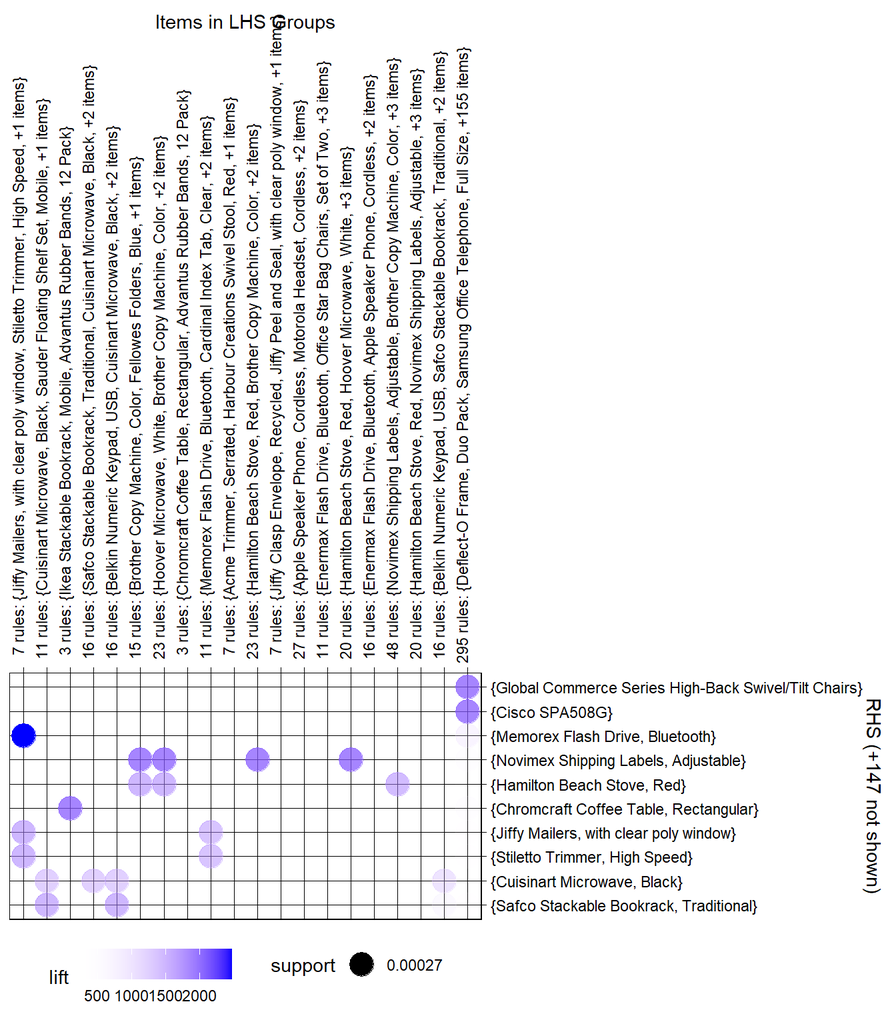

```r
#Balloon plot
plot(RulesRepc,method="grouped", col ="Blue")
```

# 4 **Conclusion**

From the above analysis, we conclude as below,  
**Customer Segment:**

- Major of customers only purchase once, with average spending amount is 481 and average return purchase are made at around 510 days
- According to the RFM heat map, high value and frequent return customer are missing, further customer data analysis based on customer type is suggested
- The output of this clustering analysis was not ideal for the interpretation. Other setting or machine learning methods should be test for carrying out better result

**Region Segment:**

- During 2012 to 2015, sales of United States ranked first in the world, and the subsequent four countries in the ranking are Australia, France, China, and Germany